# Assignment 6

Darshan Patel

2022-07-24

```r
# Add any packages you want in this chunk:
library("olsrr")
```

We are going to look at the property prices for Orange County. From there we are going to try and predict the sales price by linear regression.

# 1 Importing Data

Bring in the data and make sure the data types are correct. If not, make the proper changes. The file is located within this project. *data/prop_prices_reduced.csv*

```r
data <- read.csv("data/prop_prices_reduced.csv", header = TRUE, stringsAsFactors = FALSE)

# Should convert pool to a factor (-2)
```

# 2 Plotting

Plot histograms for all variables. Additionally, add scatterplots for the relationships between all quantitative variables.

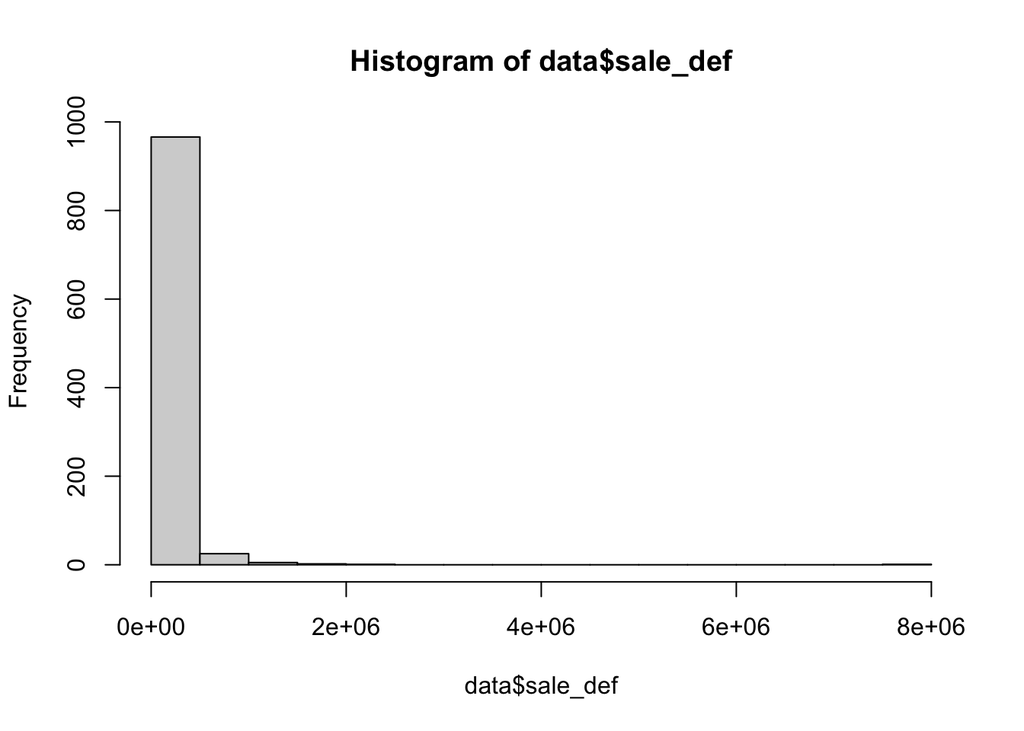

```r
hist(data$sale_def)
```

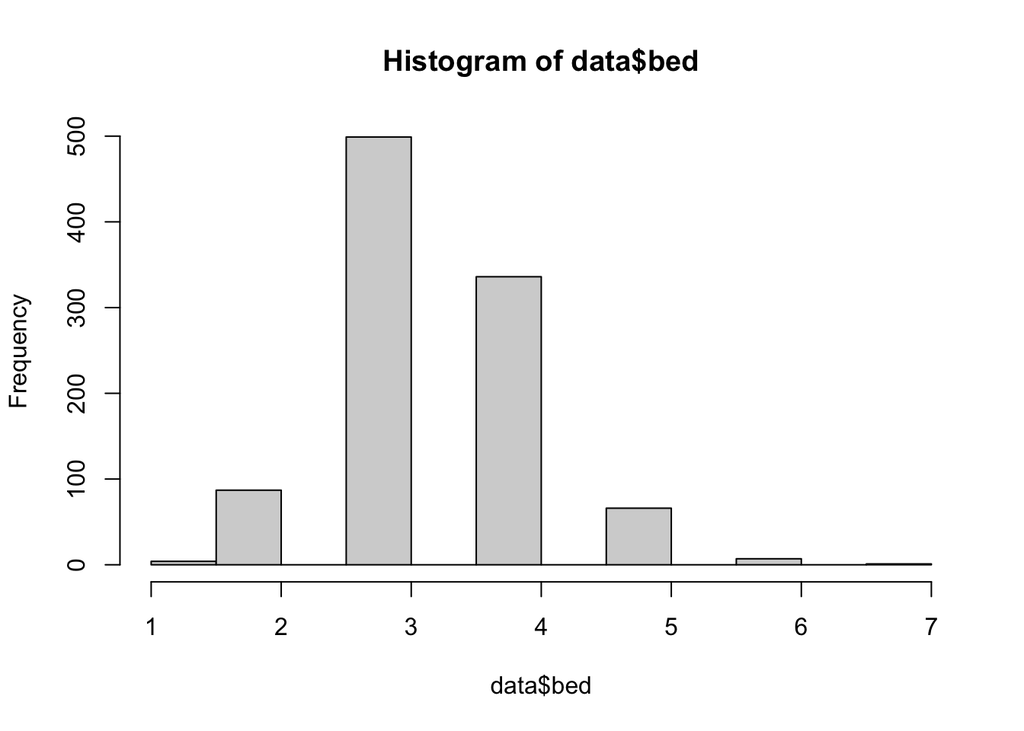

```r
hist(data$bed)
```

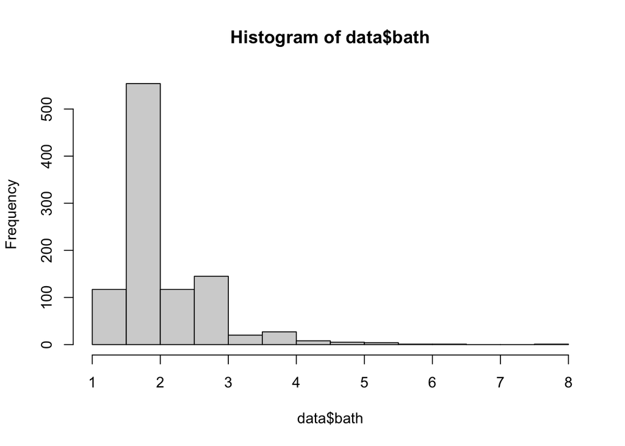

```r
hist(data$bath)
```

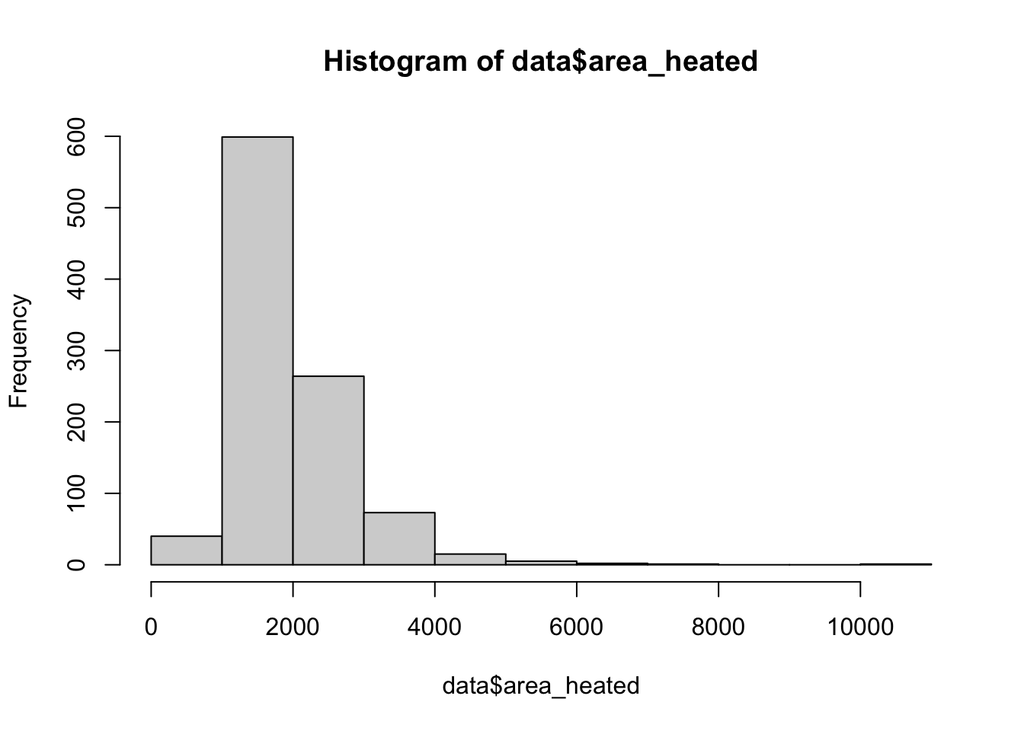

```r
hist(data$area_heated)
```

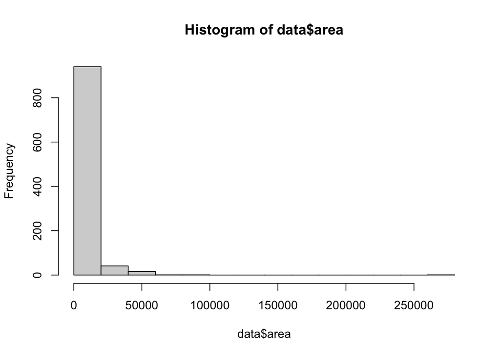

```r
hist(data$area)
```

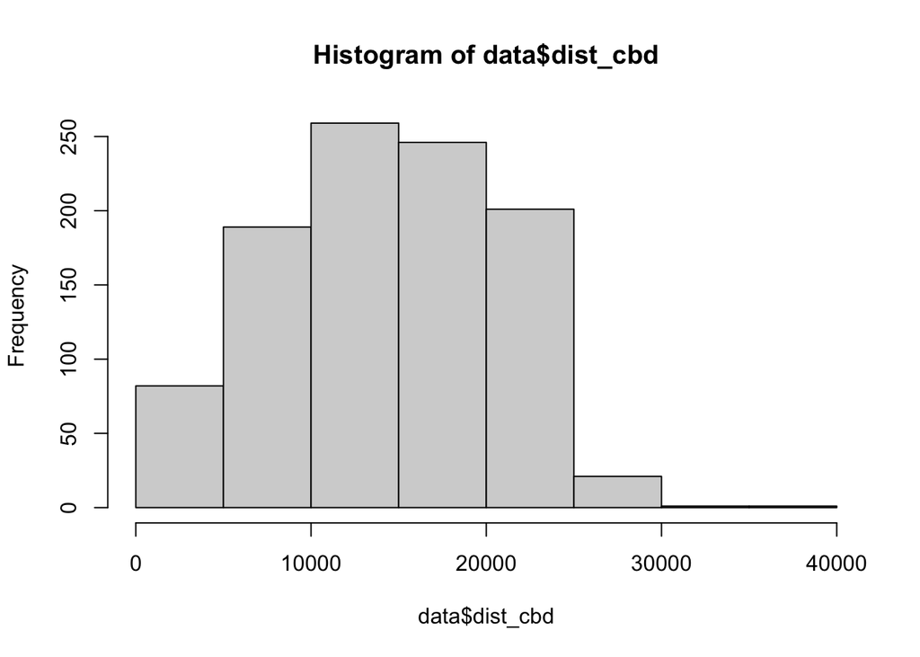

```r
hist(data$dist_cbd)
```

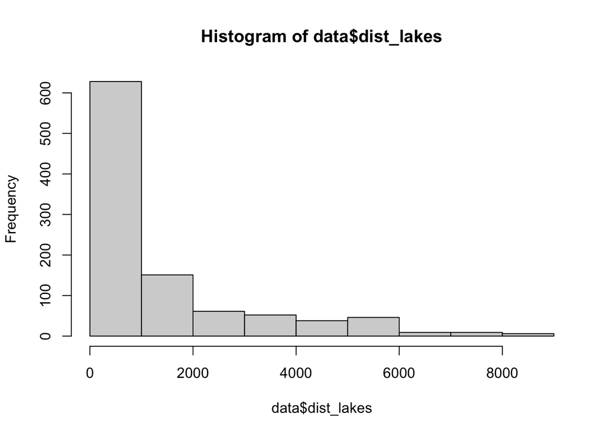

```r
hist(data$dist_lakes)
```

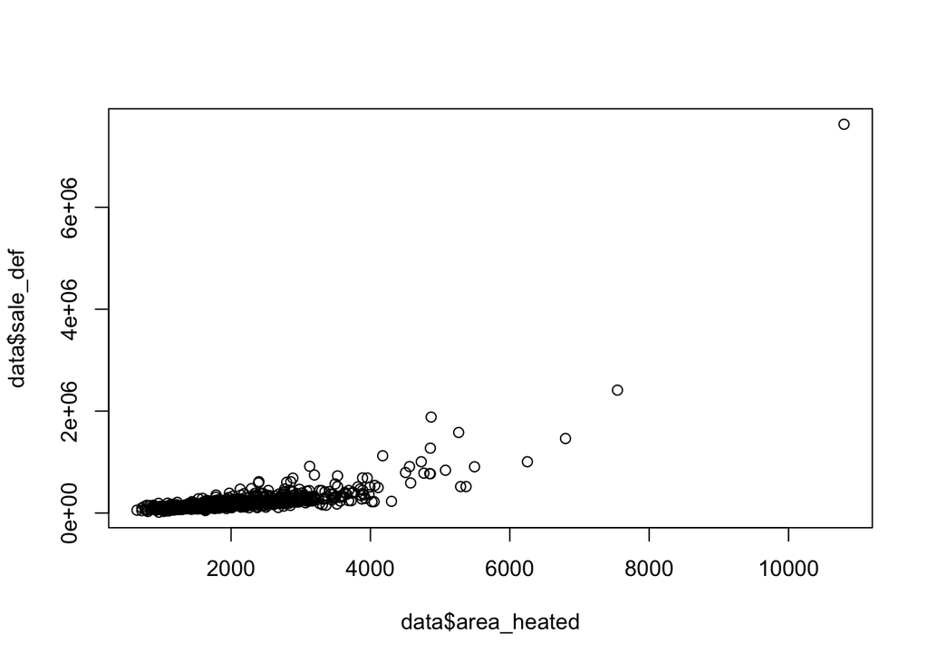

```r
# hist(data$pool) since pool is categorical, not quantitative cannot have proper histogram (-2)

plot(data$area_heated, data$sale_def)
```

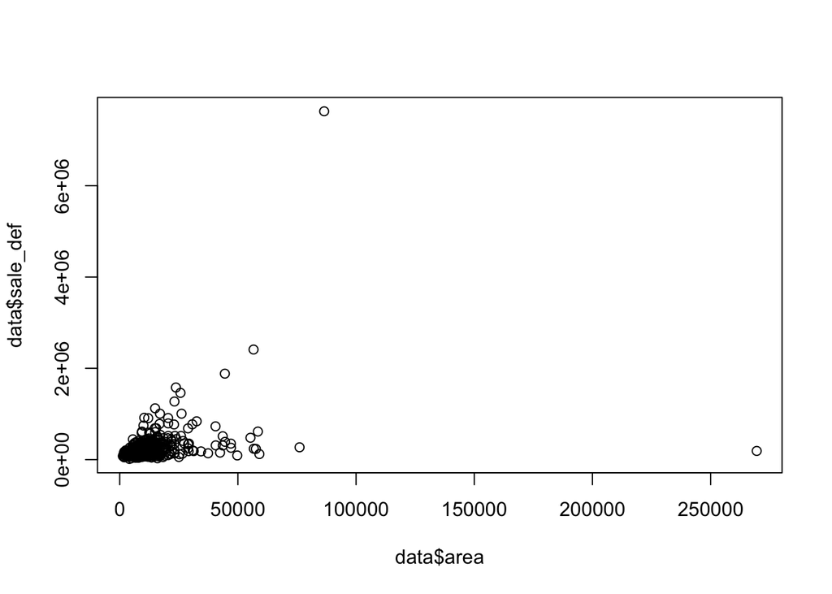

```r
plot(data$area, data$sale_def)
```

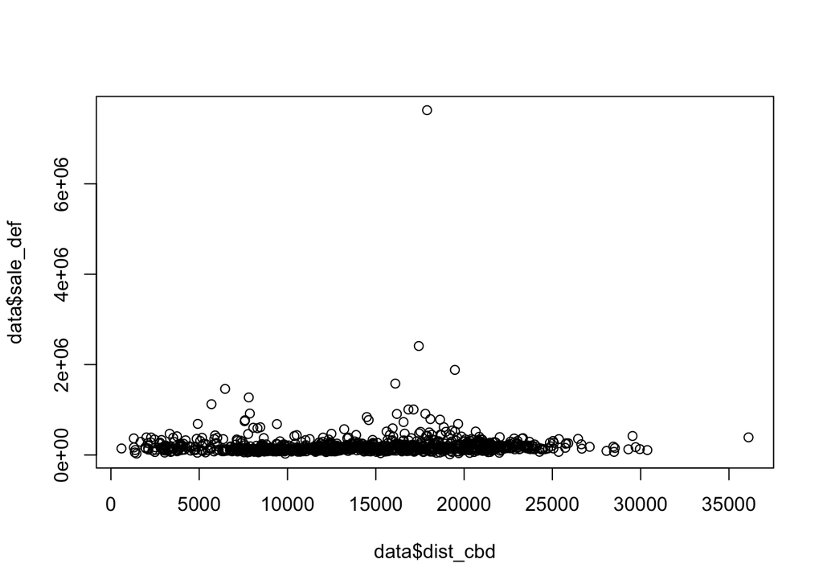

```r
plot(data$dist_cbd, data$sale_def)
```

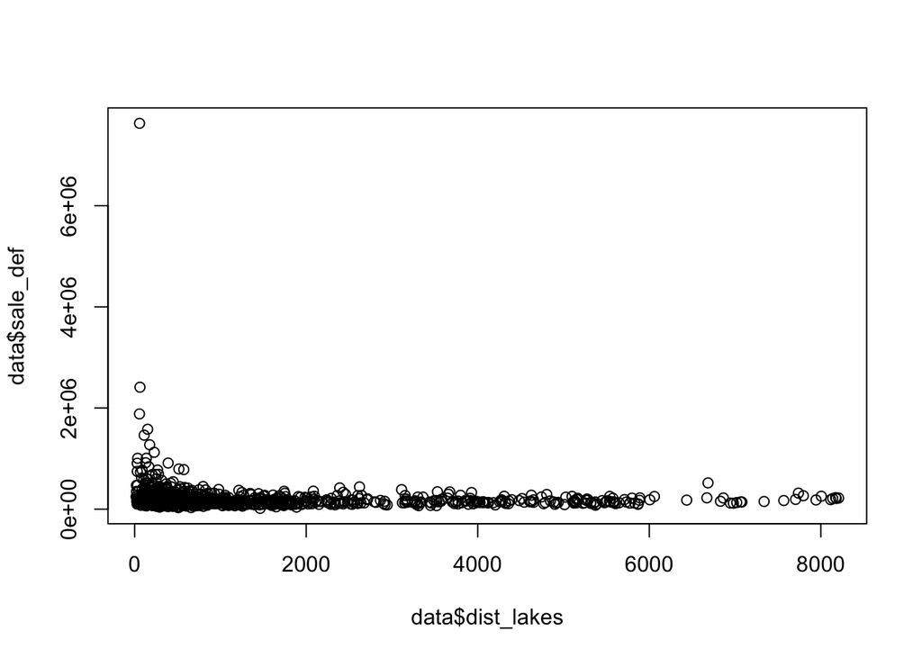

```r
plot(data$dist_lakes, data$sale_def)
```

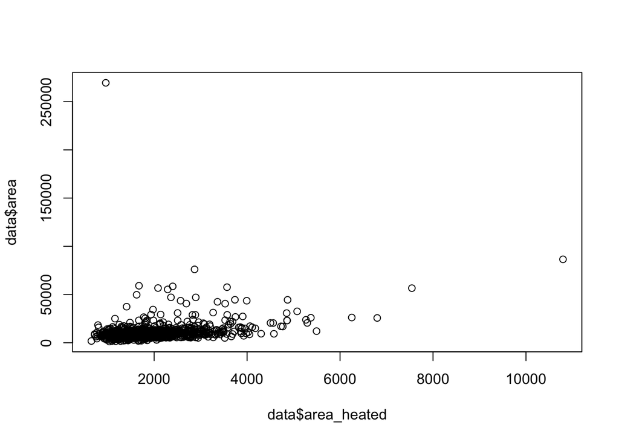

```r
plot(data$area_heated, data$area)
```

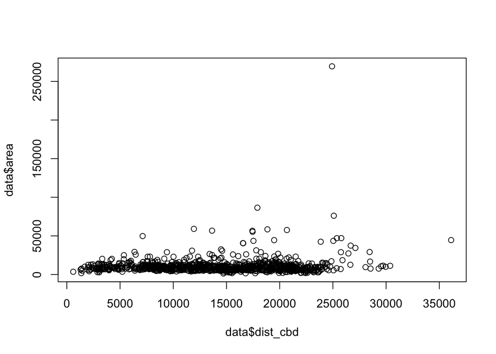

```r
plot(data$dist_cbd, data$area)
```

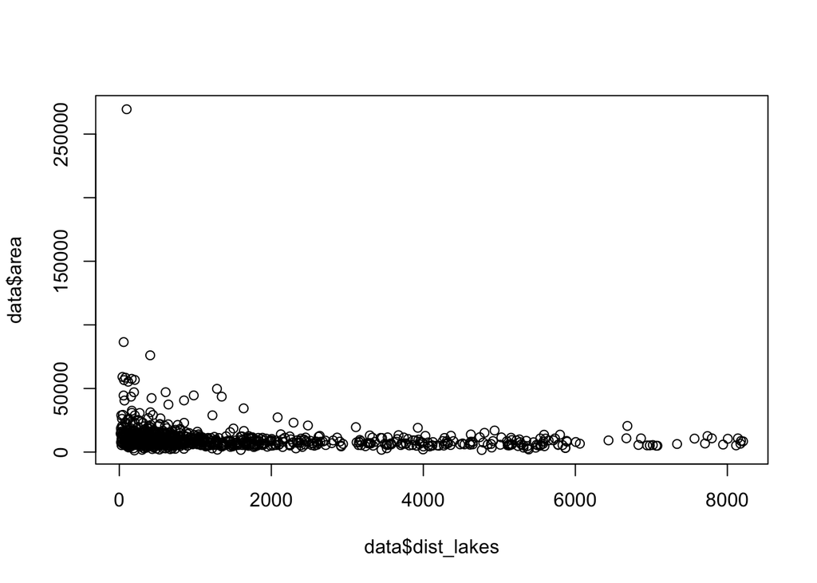

```r
plot(data$dist_lakes, data$area)
```

# 3 Summary Statistics

Provide basic summary statistics for univariate analysis. Also, provide the correlation between all the quantitative variables.

```r
summary(data)
```

```
##     sale_def            bed             bath        area_heated
##  Min.   :  15296   Min.   :1.000   Min.   :1.000   Min.   :  650
##  1st Qu.: 115565   1st Qu.:3.000   1st Qu.:2.000   1st Qu.: 1387
##  Median : 151085   Median :3.000   Median :2.000   Median : 1744
##  Mean   : 200319   Mean   :3.398   Mean   :2.248   Mean   : 1955
##  3rd Qu.: 213902   3rd Qu.:4.000   3rd Qu.:2.500   3rd Qu.: 2301
##  Max.   :7629992   Max.   :7.000   Max.   :8.000   Max.   :10796
##       area           dist_cbd         dist_lakes           pool
##  Min.   :  1307   Min.   :  598.2   Min.   :  16.74   Min.   :0.000
##  1st Qu.:  6498   1st Qu.: 9701.7   1st Qu.: 314.86   1st Qu.:0.000
##  Median :  8733   Median :14552.0   Median : 638.82   Median :0.000
##  Mean   : 10565   Mean   :14382.9   Mean   :1403.54   Mean   :0.229
##  3rd Qu.: 11250   3rd Qu.:19369.2   3rd Qu.:1735.35   3rd Qu.:0.000
##  Max.   :269496   Max.   :36107.6   Max.   :8206.79   Max.   :1.000
```

```r
# What about spread? sd/variance (-5)

cor(data$area_heated, data$sale_def)
```

```
## [1] 0.6920108
```

```r
cor(data$area, data$sale_def)
```

```
## [1] 0.3435439
```

```r
cor(data$dist_cbd, data$sale_def)
```

```
## [1] 0.052637
```

```r
cor(data$dist_lakes, data$sale_def)
```

```
## [1] -0.08857844
```

```r
cor(data$area_heated, data$area)
```

```
## [1] 0.3018432
```

```r
cor(data$dist_cbd, data$area)
```

```
## [1] 0.08648327
```

```r
cor(data$dist_lakes, data$area)
```

```
## [1] -0.1543229
```

```r
#cor(data[,-ncol(data)]) # instead of many lines
```

# 4 Regression Analysis

Run a regression with all the variables included. Print results of the regression.

```r
Model <- lm(data$sale_def ~ data$bed + data$bath + data$area_heated + data$area + data$dist_cbd + data$dist_lakes + data$pool)

print(Model)
```

```
##
## Call:
## lm(formula = data$sale_def ~ data$bed + data$bath + data$area_heated +
##     data$area + data$dist_cbd + data$dist_lakes + data$pool)
##
## Coefficients:
##      (Intercept)          data$bed         data$bath  data$area_heated
##       -5.890e+04        -8.492e+04         5.449e+04         2.439e+02
##        data$area     data$dist_cbd   data$dist_lakes         data$pool
##        3.548e+00        -5.848e+00         9.651e-01        -2.776e+04
```

```r
summary(Model)
```

```
##
## Call:
## lm(formula = data$sale_def ~ data$bed + data$bath + data$area_heated +
##     data$area + data$dist_cbd + data$dist_lakes + data$pool)
##
## Residuals:
##     Min      1Q  Median      3Q     Max
## -765238  -55999    9774   63848 4954827
##
## Coefficients:
##                    Estimate Std. Error t value Pr(>|t|)
## (Intercept)      -5.890e+04  3.093e+04  -1.904 0.057170 .
## data$bed         -8.492e+04  1.087e+04  -7.810 1.45e-14 ***
## data$bath         5.449e+04  1.507e+04   3.616 0.000315 ***
## data$area_heated  2.439e+02  1.430e+01  17.054  < 2e-16 ***
## data$area         3.548e+00  5.958e-01   5.955 3.61e-09 ***
## data$dist_cbd    -5.848e+00  1.090e+00  -5.366 1.00e-07 ***
## data$dist_lakes   9.651e-01  3.810e+00   0.253 0.800091
## data$pool        -2.776e+04  1.640e+04  -1.693 0.090787 .
## ---
## Signif. codes:  0 '***' 0.001 '**' 0.01 '*' 0.05 '.' 0.1 ' ' 1
##
## Residual standard error: 194900 on 992 degrees of freedom
## Multiple R-squared:  0.547,  Adjusted R-squared:  0.5438
## F-statistic: 171.2 on 7 and 992 DF,  p-value: < 2.2e-16
```

Which of the variables tested significant at the 95% level? Looking at the results and answering outside of the chunk is sufficient.

`pool did not test significant at the 95% level (-2)` `There are many other ones that tested significant (-8)`

## 4.1 Evaluating the model

As is, are any of the Gauss-Markov assumptions violated? If so, which ones? How can you fix the issues?

```r
ols_vif_tol(Model)
```

```
##          Variables Tolerance      VIF
## 1         data$bed 0.5151412 1.941215
## 2        data$bath 0.2897950 3.450715
## 3 data$area_heated 0.2449209 4.082951
## 4        data$area 0.8595293 1.163427
## 5    data$dist_cbd 0.8499874 1.176488
## 6  data$dist_lakes 0.8915599 1.121630
## 7        data$pool 0.8002207 1.249655
```

based on the VIF factor, multicollinearity does not seem to be an issue in regards to the assumptions. Assuming no other assumptions are violated since random disturbance is unknown and other assumptions rely on random disturbance

`Only checked one part of one of the Gauss-Markov assumptions (-22)`

## 4.2 New Model

Based off of your findings in the previous section, make changes to the variables, the functional form, etc.

```r
# No changes to be made.

# Many changes were needed (-10)
```

# 5 Prediction

Based on the following inputs, predict the deflated sales price:

- 2 bed
- 2 bath
- area_heated = 1223
- area = 9750
- dist_cbd = 19368
- dist_lakes = 490
- no pool

```r
Price = (-8.492e+04*2) + (5.449e+04*2) + (2.439e+02*1223) + (3.548e+00*9750) + (-5.848e+00*19368) + (9.651e-01*490) + (-2.776e+04*0)

# Careful with the "=" for assignment. It will cause issues in many places use " <-" instead (-1)

print(Price)
```

```
## [1] 159231.5
```

```r
# Values were hard coded, you should use the predict function. Otherwise, you will need to manually type in values for each prediction. (-1)
```